# SAT_Practice_0318

Question ID: 09_413

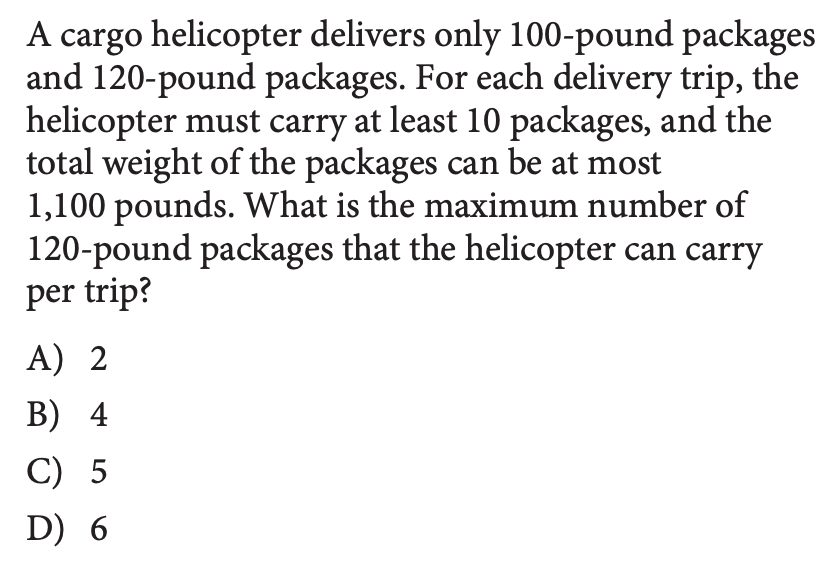

ABCD

The correct answer is C

Question ID: 11_210

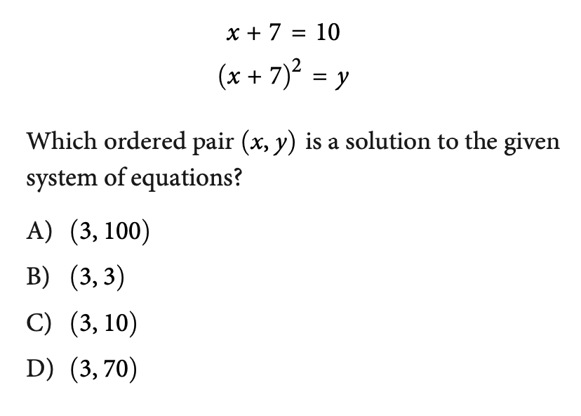

ABCD

The correct answer is A

Question ID: 13_209

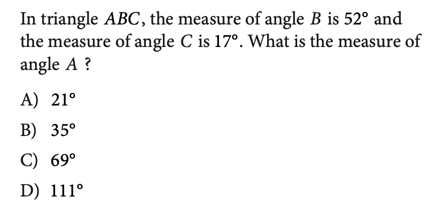

ABCD

The correct answer is D

Question ID: 06_408

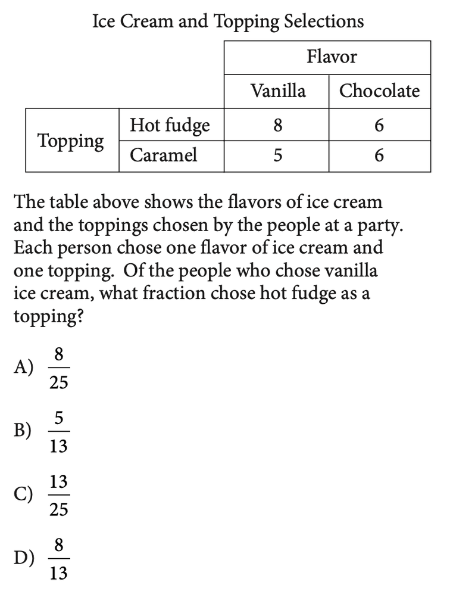

ABCD

The correct answer is D

Question ID: 10_422

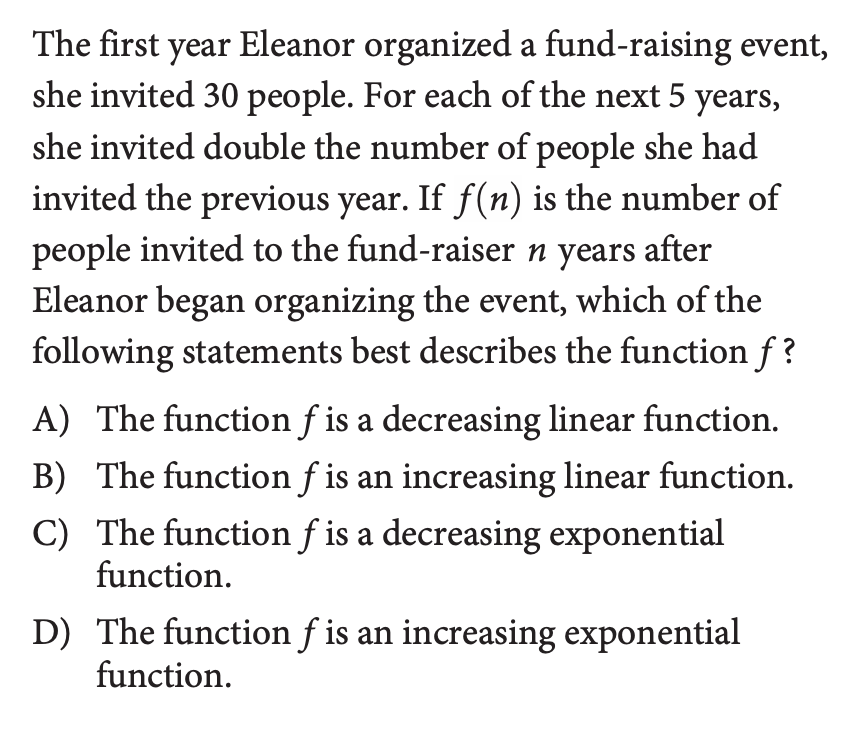

ABCD

The correct answer is D

Question ID: 07_309

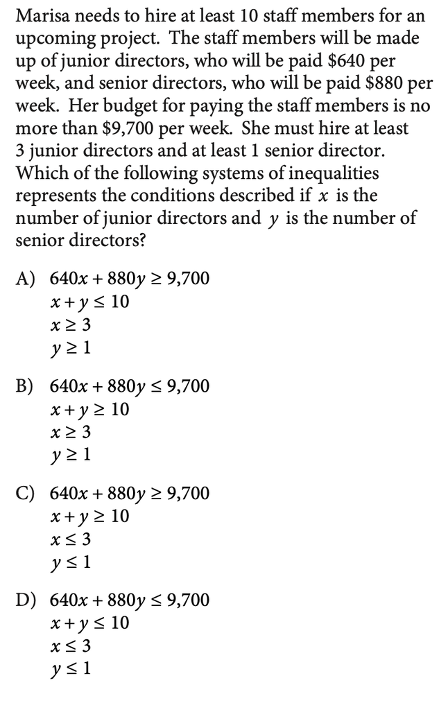

ABCD

The correct answer is B

Question ID: 13_207

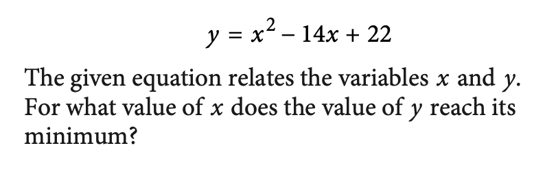

The correct answer is 7.

Question ID: 03_405

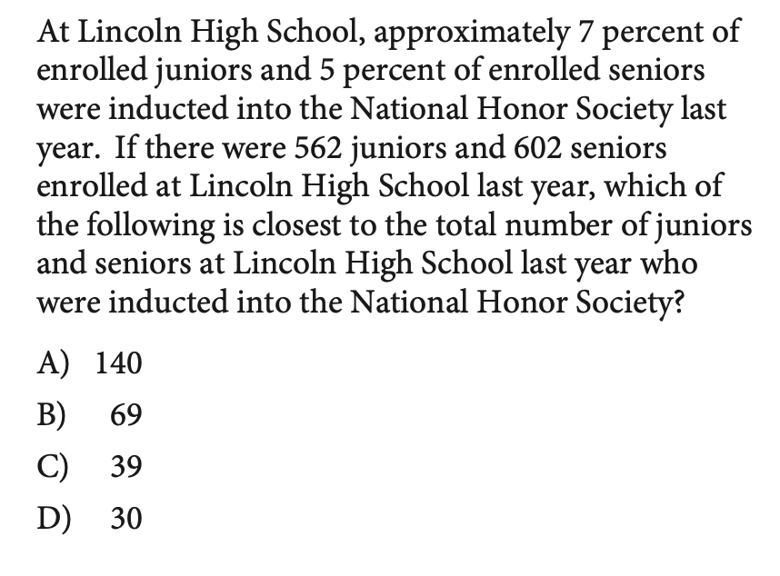

ABCD

The correct answer is B

Question ID: 04_305

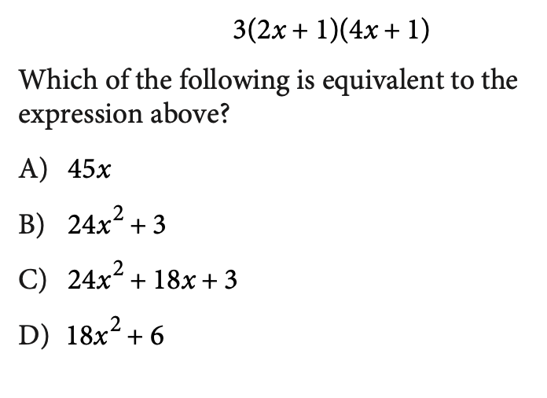

ABCD

The correct answer is C

Question ID: 11_121

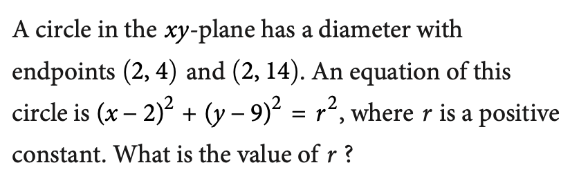

The correct answer is 5.

Question ID: 14_117

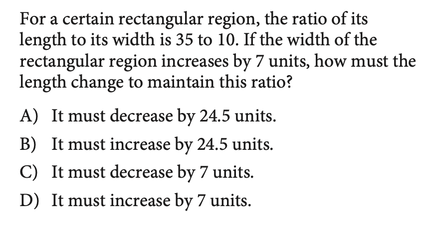

ABCD

The correct answer is B

Question ID: 09_434

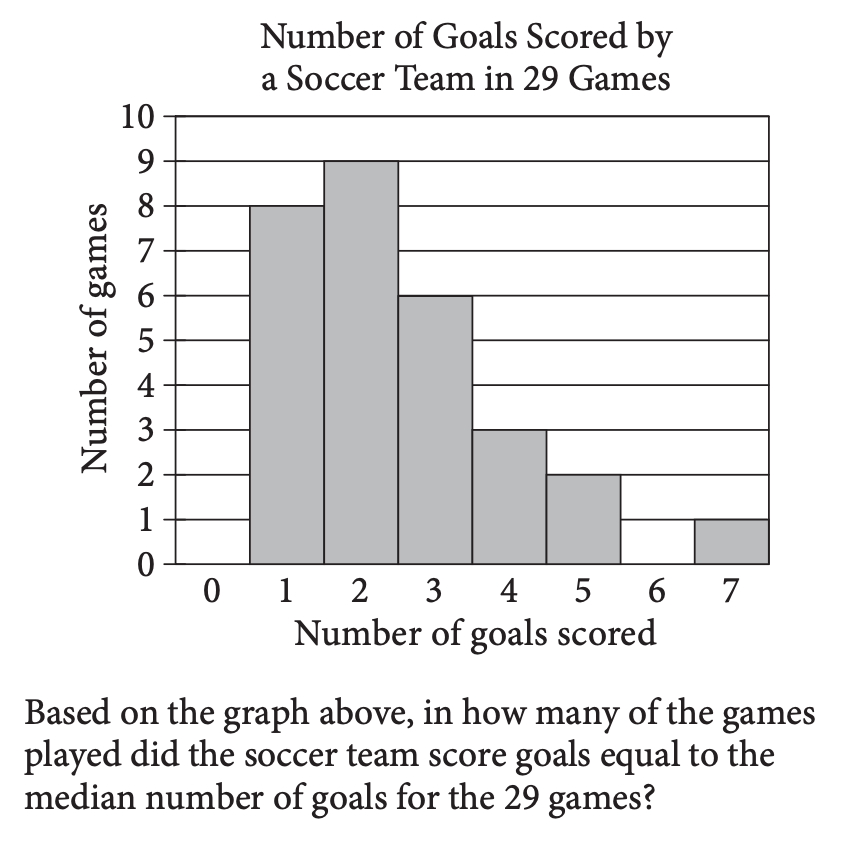

The correct answer is 9.

Question ID: 13_214

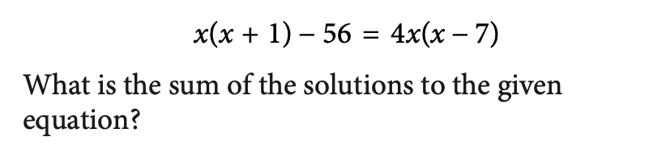

Anything between 9.66 and 9.67 should be marked correct.

Question ID: 03_427

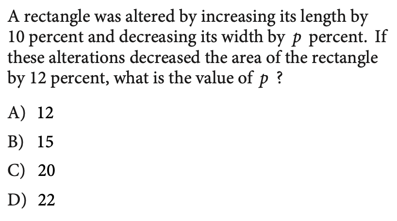

ABCD

The correct answer is C

Question ID: 07_437

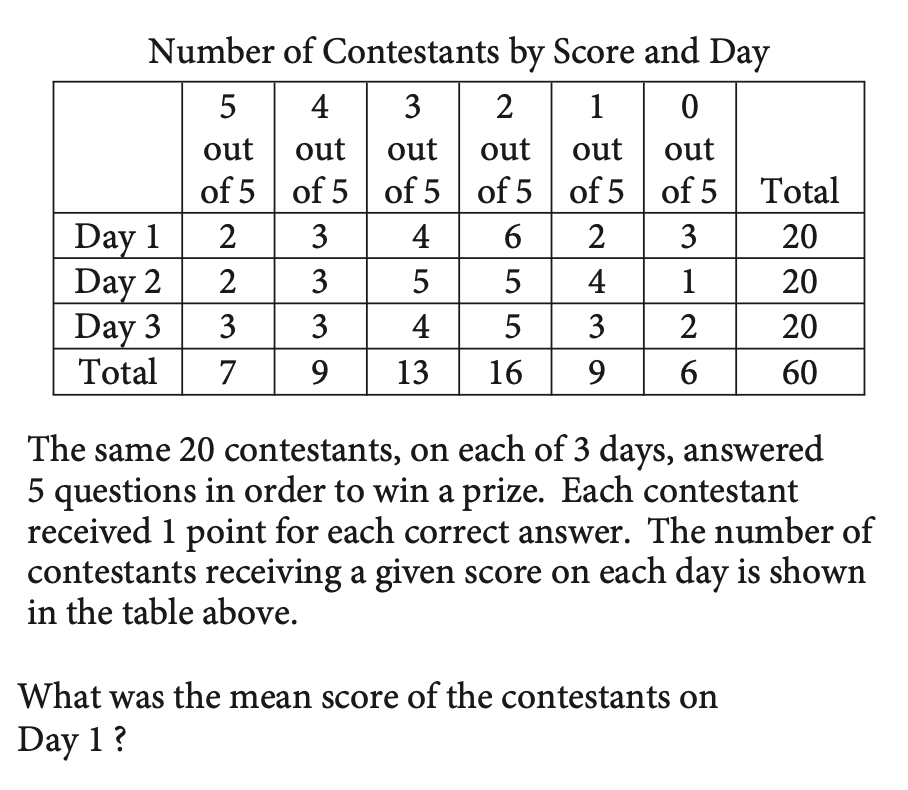

The correct answer is 2.4.

Question ID: 14_101

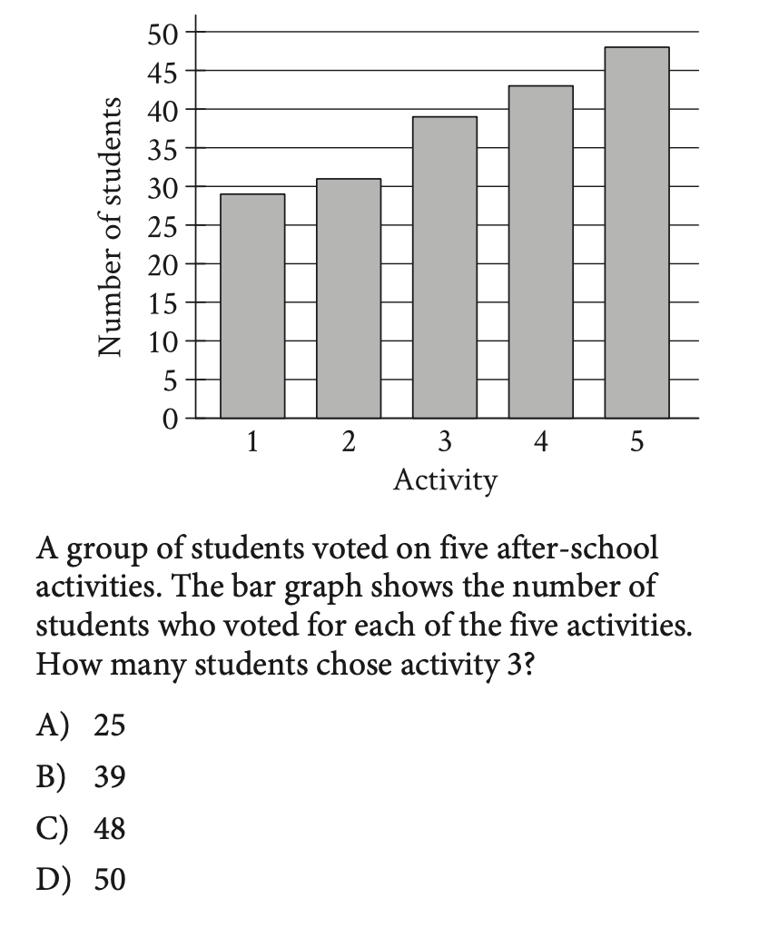

ABCD

The correct answer is B

Question ID: 11_217

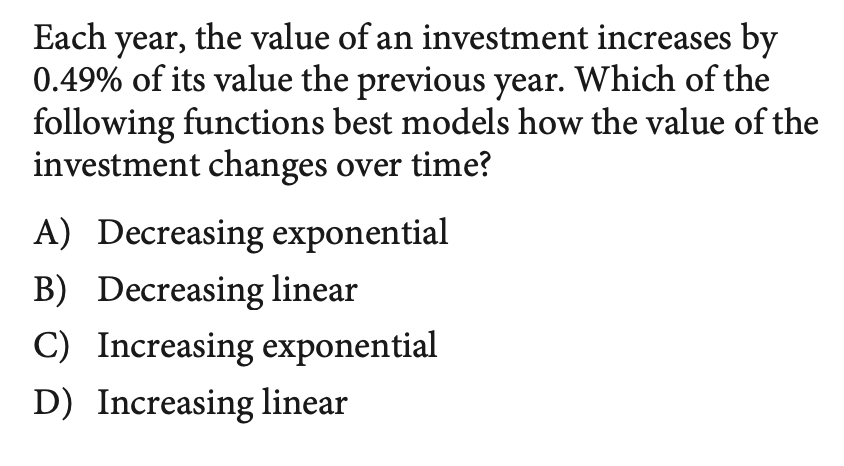

ABCD

The correct answer is C

Question ID: 12_226

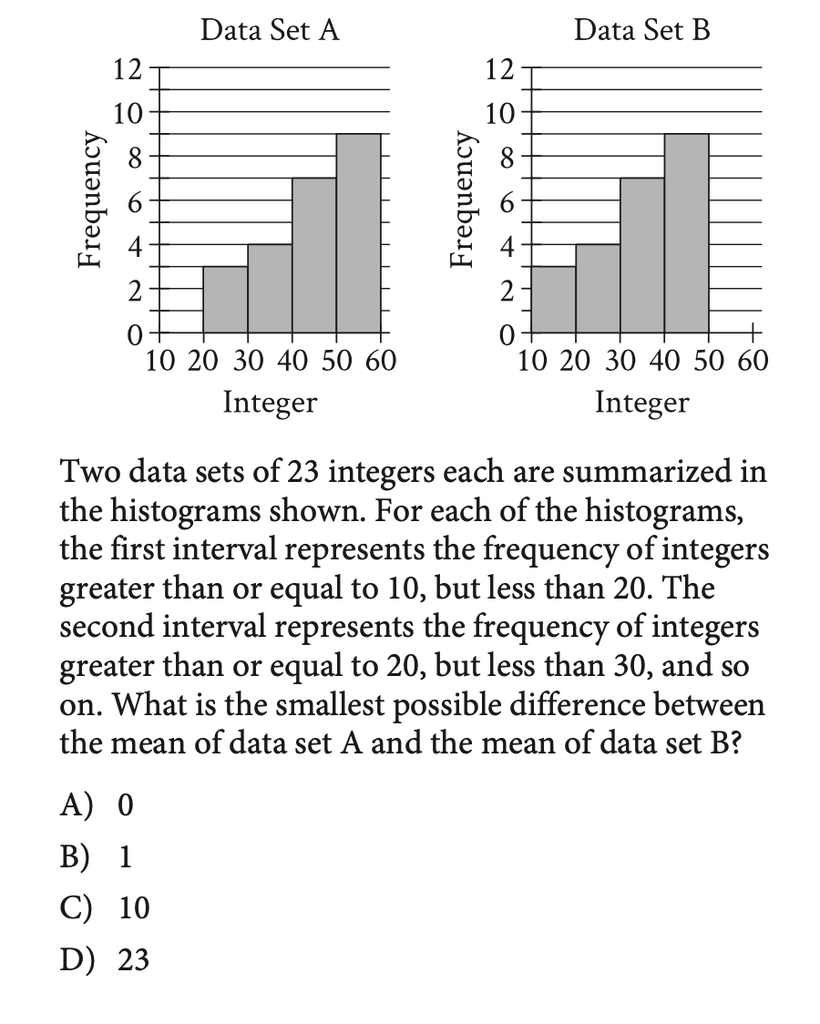

ABCD

The correct answer is B

Question ID: 05_405

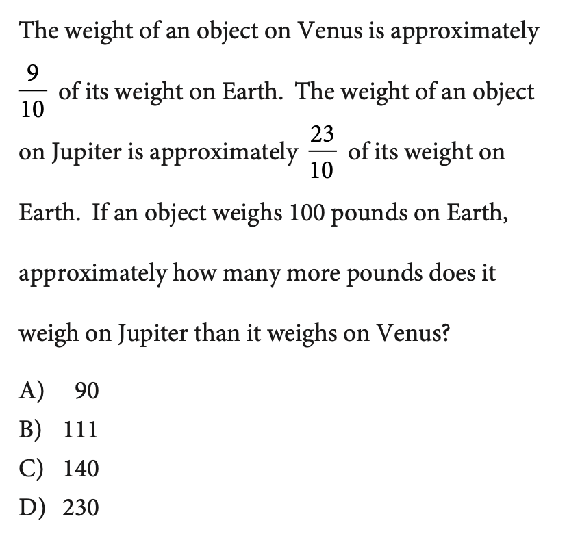

ABCD

The correct answer is C

Question ID: 02_401

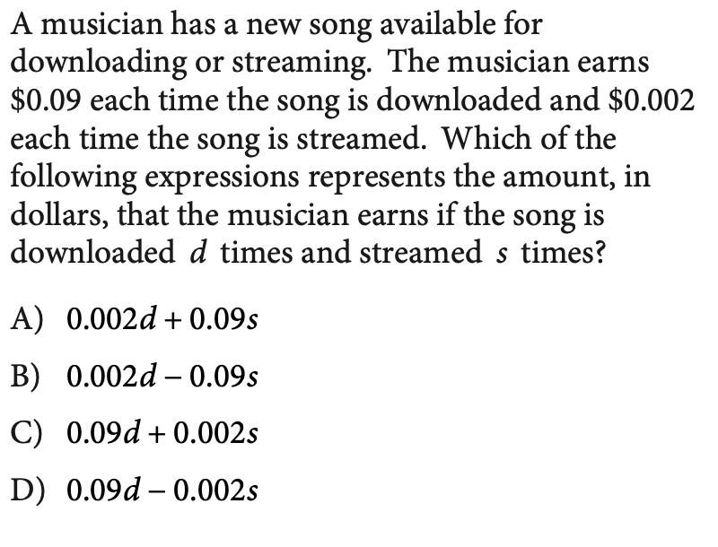

ABCD

The correct answer is C

Question ID: 04_437

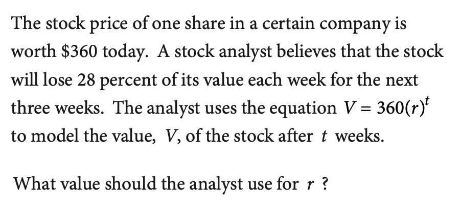

The correct answer is 0.72.

Question ID: 09_316

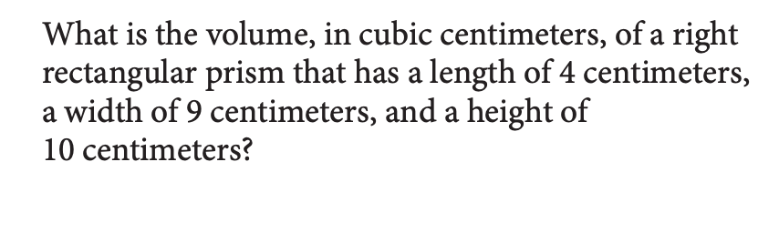

The correct answer is 360.

Question ID: 07_310

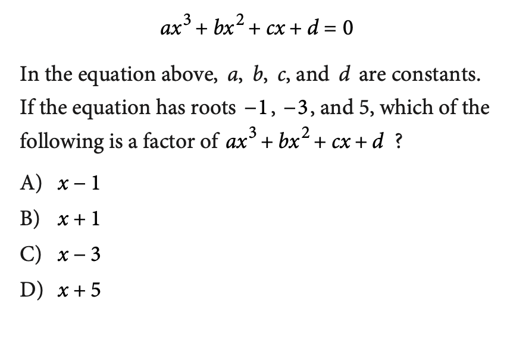

ABCD

The correct answer is B

Question ID: 05_408

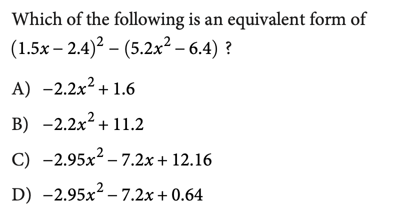

ABCD

The correct answer is C

Question ID: 01_437

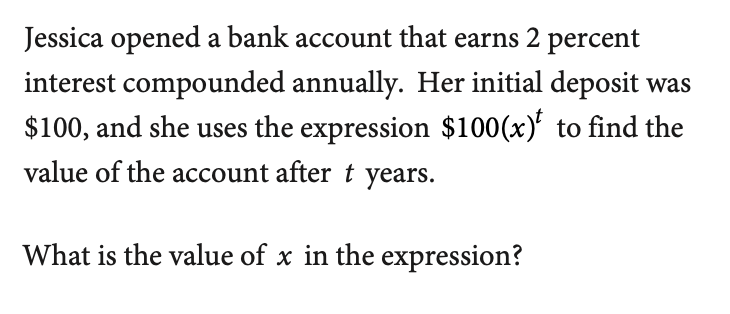

The correct answer is 1.02.

Question ID: 10_319

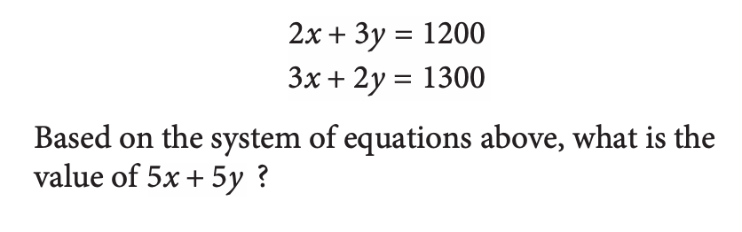

The correct answer is 2500.

Question ID: 13_121

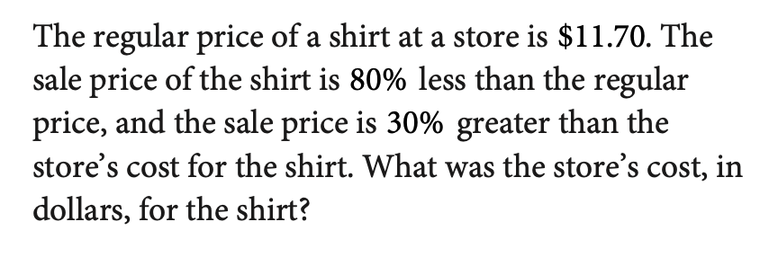

The correct answer is 1.8.

Question ID: 12_127

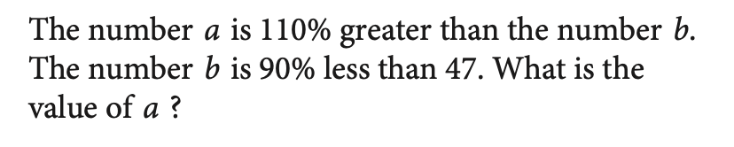

The correct answer is 9.87.